# midterm project

# Introduction

The prevalence and patterns of tobacco use in the United States vary significantly by state, influenced by factors such as demographics, cultural norms, public health initiatives, and socioeconomic status. Alaska and Alabama, while both part of the U.S., represent two very different demographic and geographic profiles, with Alaska being sparsely populated and geographically isolated, and Alabama situated in the more densely populated and historically tobacco-favoring southeastern region. This project aims to examine tobacco use patterns in both states, focusing on traditional tobacco products (e.g., cigarettes, smokeless tobacco) and newer products like e-cigarettes.The choice of Alaska and Alabama offers a unique opportunity to observe how tobacco consumption may differ between a northern, frontier-like environment and a southern state with a rich history of tobacco agriculture and use. By analyzing data from 2011 to 2019, we aim to uncover trends and impacts of tobacco use policies, including the rise of e-cigarettes, and to understand whether geographic, cultural, or socioeconomic differences significantly influence these patterns. Ultimately, this analysis will contribute to a deeper understanding of regional tobacco use dynamics and provide insights to inform targeted public health interventions.

The dataset I choose - Tobacco use in Alabama and Alaska from 2011 to 2019

Reference website: https://data.cdc.gov/Survey-Data/Behavioral-Risk-Factor-Data-Tobacco-Use-2011-to-pr/wsas-xwh5/about_data

# The research of question

How has tobacco use, including traditional cigarettes, smokeless tobacco, Cessation and e-cigarettes, changed over time in Alaska and Alabama from 2017 to 2019?

# Loading the data set

```r
library(dplyr)
library(data.table)
library(tidyverse)
library(ggplot2)
Tob.Use<- data.table::fread("/Users/kristydeng/Downloads/wsas-xwh5.csv")
Tob.Use <- Tob.Use %>%
  rename(
    state = locationabbr,
    City = locationdesc
  )
Tob.Use <- Tob.Use %>%
  filter(year %in% c(2017, 2018, 2019))
```

# Cleaning the data

The data set is from 2011 to 2019. By the raw data comparison I realized that Alaska is stats from 2017. The data prior to 2017 is not comparable. Thus, I need to delete the data prior to 2017,

```r
Tob.Use <- Tob.Use %>%
  filter(year %in% c(2017, 2018, 2019))
Tob.Use <- Tob.Use %>%
  filter(!is.na(data_value))
```

# Research

```r
library(dplyr)
alabama_counts <- Tob.Use %>%
  filter(City == "Alabama") %>%
  group_by(year, topicdesc) %>%
  summarise(count = n())
alabama_counts
```

```
# A tibble: 10 × 3
# Groups:   year [3]
   year  topicdesc                      count
   <chr> <chr>                          <int>
 1 2017  Cessation (Adults)                 6
 2 2017  Cigarette Use (Adults)            33
 3 2017  E-Cigarette Use (Adults)          33
 4 2017  Smokeless Tobacco Use (Adults)    30
 5 2018  Cessation (Adults)                 6
 6 2018  Cigarette Use (Adults)            33
 7 2018  Smokeless Tobacco Use (Adults)    28
 8 2019  Cessation (Adults)                 6
 9 2019  Cigarette Use (Adults)            33
10 2019  Smokeless Tobacco Use (Adults)    30
```

```r
library(dplyr)
alaska_counts <- Tob.Use %>%
  filter(City == "Alaska") %>%
  group_by(year, topicdesc,) %>%
  summarise(count = n())
alaska_counts
```

```
# A tibble: 11 × 3
# Groups:   year [3]
   year  topicdesc                      count
   <chr> <chr>                          <int>
 1 2017  Cessation (Adults)                 1
 2 2017  Cigarette Use (Adults)             1
 3 2017  E-Cigarette Use (Adults)           2
 4 2017  Smokeless Tobacco Use (Adults)     3
 5 2018  Cessation (Adults)                 6
 6 2018  Cigarette Use (Adults)            33
 7 2018  E-Cigarette Use (Adults)          31
 8 2018  Smokeless Tobacco Use (Adults)    28
 9 2019  Cessation (Adults)                 6
10 2019  Cigarette Use (Adults)            33
11 2019  Smokeless Tobacco Use (Adults)    28
```

#3.How has tobacco use among adults in Alabama and Alaska changed over time from 2017 to 2019?

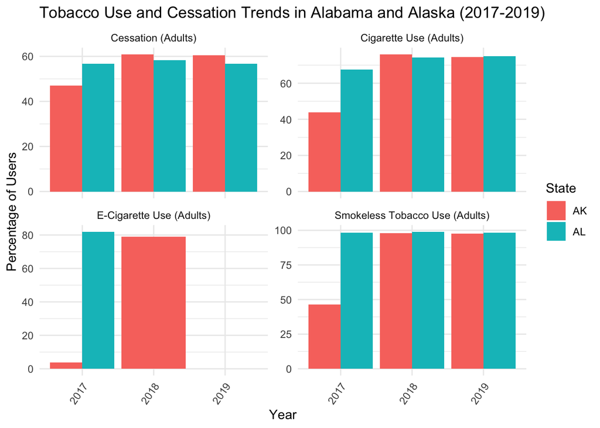

```r
library(ggplot2)
library(dplyr)
filtered_data <- Tob.Use %>%
  filter(state %in% c("AL", "AK"), year >= 2017, year <= 2019) %>%
  filter(!is.na(data_value)) %>%
  filter(topicdesc %in% c("Smokeless Tobacco Use (Adults)",
                          "E-Cigarette Use (Adults)",
                          "Cigarette Use (Adults)",
                          "Cessation (Adults)"))
ggplot(filtered_data, aes(x = as.factor(year), y = data_value, fill = state)) +
  geom_bar(stat = "identity", position = "dodge") +
  facet_wrap(~ topicdesc, scales = "free_y") +
  labs(
    title = "Tobacco Use and Cessation Trends in Alabama and Alaska (2017-2019)",
    x = "Year",
    y = "Percentage of Users",
    fill = "State"
  ) +
  theme_minimal() +
  theme(axis.text.x = element_text(angle = 55, hjust = 1))
```

#4.How does tobacco use vary between males and females in Alabama and Alaska from 2017 to 2019?(The gender summary table will highlight whether males or females are more likely to use tobacco products)

```r
library(ggplot2)
library(dplyr)
summary_by_gender <- Tob.Use %>%
  filter(gender != "Overall") %>%
  group_by(state, gender, topicdesc) %>%
  summarise(
    mean_usage = mean(data_value, na.rm = TRUE),
    sd_usage = sd(data_value, na.rm = TRUE),
    count = n()
  )
summary_by_gender
```

```
# A tibble: 16 × 6
# Groups:   state, gender [4]
   state gender topicdesc                      mean_usage sd_usage count
   <chr> <chr>  <chr>                               <dbl>    <dbl> <int>
 1 AK    Female Cessation (Adults)                   57.6     2.79     4
 2 AK    Female Cigarette Use (Adults)               33.6    23.2     14
 3 AK    Female E-Cigarette Use (Adults)             22.4    32.0      5
 4 AK    Female Smokeless Tobacco Use (Adults)       26.2    44.2      8
 5 AK    Male   Cessation (Adults)                   54.5     6.77     4
 6 AK    Male   Cigarette Use (Adults)               36.7    18.2     12
 7 AK    Male   E-Cigarette Use (Adults)             26.9    27.4      8
 8 AK    Male   Smokeless Tobacco Use (Adults)       42.1    32.4     10
 9 AL    Female Cessation (Adults)                   53.6     2.80     6
10 AL    Female Cigarette Use (Adults)               34.2    21.7     21
11 AL    Female E-Cigarette Use (Adults)             29.8    32.9      7
12 AL    Female Smokeless Tobacco Use (Adults)       31.8    39.8     16
13 AL    Male   Cessation (Adults)                   55.8     1.67     6
14 AL    Male   Cigarette Use (Adults)               37.1    16.4     18
15 AL    Male   E-Cigarette Use (Adults)             34.4    29.7      6
16 AL    Male   Smokeless Tobacco Use (Adults)       42.3    30.8     15
```

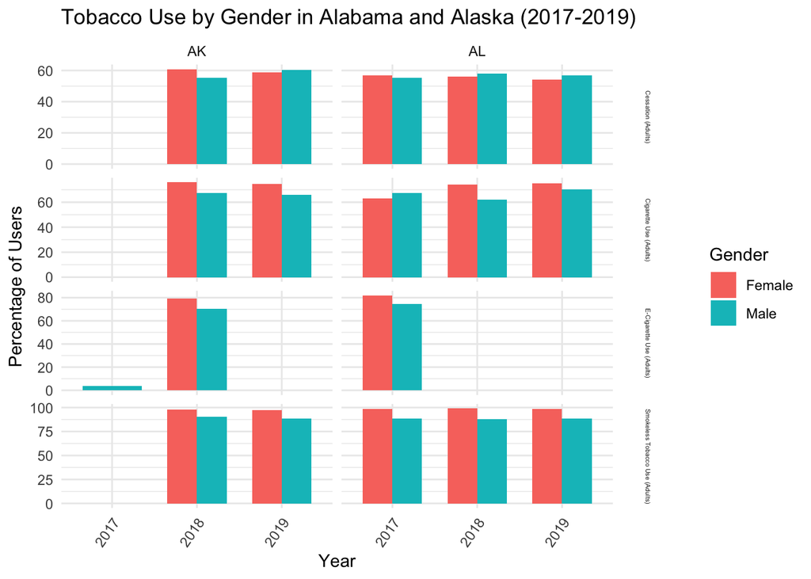

```r
filtered_data_gender <- Tob.Use %>%
  filter(state %in% c("AL", "AK"), year >= 2017, year <= 2019) %>%
  filter(topicdesc %in% c("Smokeless Tobacco Use (Adults)",
                          "E-Cigarette Use (Adults)",
                          "Cigarette Use (Adults)",
                          "Cessation (Adults)")) %>%
  filter(!is.na(data_value)) %>%
  filter(gender %in% c("Female", "Male"))  # Exclude "overall"
ggplot(filtered_data_gender, aes(x = as.factor(year), y = data_value, fill = gender)) +
  geom_bar(stat = "identity", position = "dodge",width = 0.7) +
  facet_grid(topicdesc ~ state, scales = "free_y") +
  labs(
    title = "Tobacco Use by Gender in Alabama and Alaska (2017-2019)",
    x = "Year",
    y = "Percentage of Users",
    fill = "Gender"
  ) +
  theme_minimal() +
  theme(axis.text.x = element_text(angle = 55, hjust = 1),
    strip.text.y = element_text(size = 4, margin = margin(20, 20, 20, 20))
  )
```

#5.How does the average tobacco use differ between Alabama and Alaska across the years 2017-2019? (the table grouped by state will show the overall tobacco use trends in Alabama and Alaska)

```r
summary_by_state <- Tob.Use %>%
  filter(year >= 2017, year <= 2019, state %in% c("AL", "AK")) %>%
  filter(!is.na(data_value)) %>%
  group_by(state, topicdesc) %>%
  summarise(
    mean_usage = mean(data_value, na.rm = TRUE),
    sd_usage = sd(data_value, na.rm = TRUE),
    count = n()
  )
summary_by_state
```

```
# A tibble: 8 × 5
# Groups:   state [2]
  state topicdesc                      mean_usage sd_usage count
  <chr> <chr>                               <dbl>    <dbl> <int>
1 AK    Cessation (Adults)                   55.4     4.86    13
2 AK    Cigarette Use (Adults)               30.1    18.2     67
3 AK    E-Cigarette Use (Adults)             18.6    24.0     33
4 AK    Smokeless Tobacco Use (Adults)       22.3    29.4     59
5 AL    Cessation (Adults)                   54.8     2.11    18
6 AL    Cigarette Use (Adults)               30.4    16.9     99
7 AL    E-Cigarette Use (Adults)             20.9    26.4     33
8 AL    Smokeless Tobacco Use (Adults)       23.2    29.8     88
```

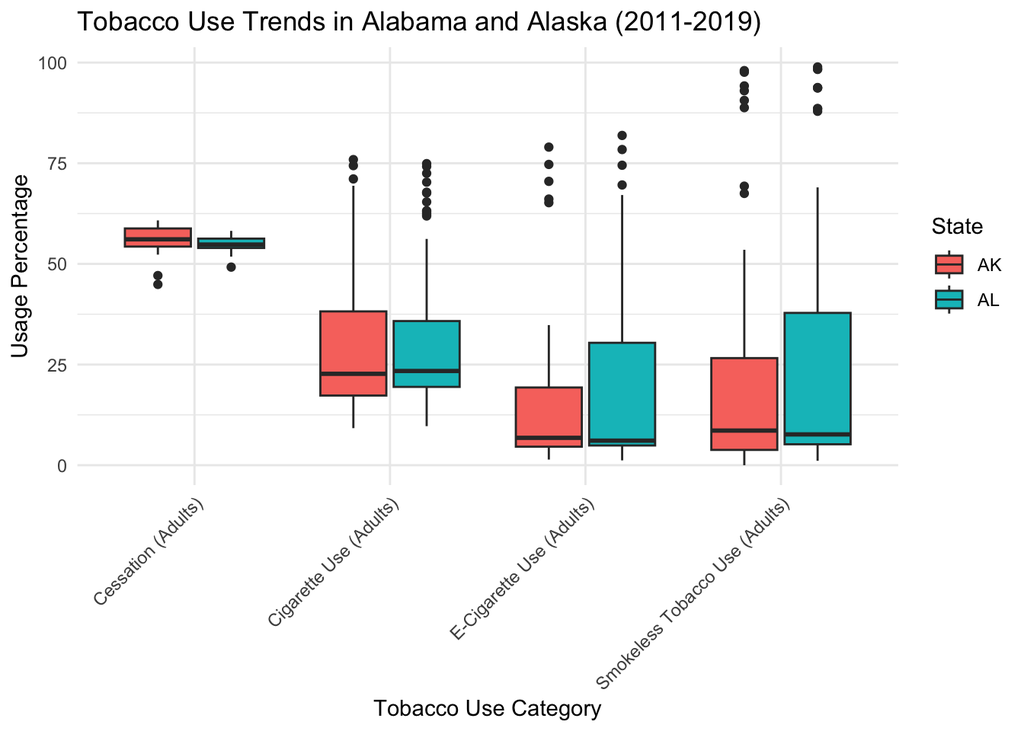

```r
ggplot(Tob.Use %>% filter(year >= 2017, year <= 2019), aes(x = topicdesc, y = data_value, fill = state)) +
  geom_boxplot() +
  labs(
    title = "Tobacco Use Trends in Alabama and Alaska (2011-2019)",
    x = "Tobacco Use Category",
    y = "Usage Percentage",
    fill = "State"
  ) +
  theme_minimal() +
  theme(axis.text.x = element_text(angle = 45, hjust = 1))
```

Analyze：The average cessation rate in Alaska (55.38%) is slightly higher than in Alabama (54.76%). This suggests that a higher percentage of adults in Alaska are attempting to quit tobacco use compared to Alabama. The low standard deviation for cessation in both states implies a consistent cessation rate over time. The boxplot further supports this, showing minimal variability for cessation rates, indicating that efforts to encourage quitting have been similarly effective in both states.Both Alaska and Alabama have similar average cigarette use rates among adults, with Alaska at 30.13% and Alabama at 30.40%. However, the boxplot reveals that Alaska has more variability in cigarette usage compared to Alabama, indicating fluctuations in use over time or among different demographics.The wider distribution in Alaska’s cigarette use rates suggests potential differences in subpopulations or regions within the state, with some years or groups experiencing higher usage rates.E-cigarette use is slightly higher in Alabama (20.94%) compared to Alaska (18.60%). Both states show high variability in e-cigarette use, as indicated by the high standard deviations. The boxplot also highlights significant variation, suggesting evolving trends in e-cigarette adoption between the two states. This variability might be influenced by differing public attitudes, regulatory measures, or access to e-cigarette products during this period.The average smokeless tobacco use is higher in Alabama (23.16%) compared to Alaska (22.33%). The boxplot shows that Alabama has a broader range in smokeless tobacco use, indicating a wider spread across different years or subgroups. Despite the higher average usage in Alabama, both states have similar levels of variability, suggesting stable usage patterns within each state. The wider box in Alabama implies more variability in how smokeless tobacco is used, likely driven by cultural factors or differing social acceptance. Overall, The boxplot illustrates that cessation rates are consistently high and stable across both states, whereas other forms of tobacco (cigarettes, e-cigarettes, smokeless tobacco) have more variability and generally lower median usage percentages. Alabama generally shows slightly higher average usage across different tobacco categories except for cessation, where Alaska has the lead. The high standard deviations observed in cigarette and e-cigarette usage indicate that these tobacco products have not reached a stable usage pattern, reflecting changes in public perception, regulation, or access to alternative tobacco products over time. The Public Health impact: The relatively high cessation rates in both Alaska and Alabama indicate that smoking cessation programs and awareness campaigns are effective. However, the variability in cigarette, e-cigarette, and smokeless tobacco usage calls for more targeted interventions, particularly in Alabama, where usage rates and variability are higher. Further efforts could focus on reducing the adoption of e-cigarettes and smokeless tobacco among young adults and addressing the factors contributing to these trends, ultimately leading to improved public health outcomes in both states.

#6.Analysis of Tobacco Use by Education Level in Alabama and Alaska (2017-2019)

```r
library(dplyr)
library(ggplot2)
edu_summary <- Tob.Use %>%
  filter(year >= 2017, year <= 2019,
         state %in% c("AL", "AK"),
         education != "All Grades") %>%
  filter(!is.na(data_value)) %>%
  group_by(state, education) %>%
  summarise(
    mean_usage = mean(data_value, na.rm = TRUE),
    sd_usage = sd(data_value, na.rm = TRUE),
    count = n()
  )
print(edu_summary)
```

```
# A tibble: 6 × 5
# Groups:   state [2]
  state education    mean_usage sd_usage count
  <chr> <chr>             <dbl>    <dbl> <int>
1 AK    12th Grade        15.8     10.5     10
2 AK    < 12th Grade      27.1     16.7     11
3 AK    > 12th Grade       6.94     3.88    11
4 AL    12th Grade        14.7      9.47    14
5 AL    < 12th Grade      19.7     13.8     14
6 AL    > 12th Grade       8.81     5.10    14
```

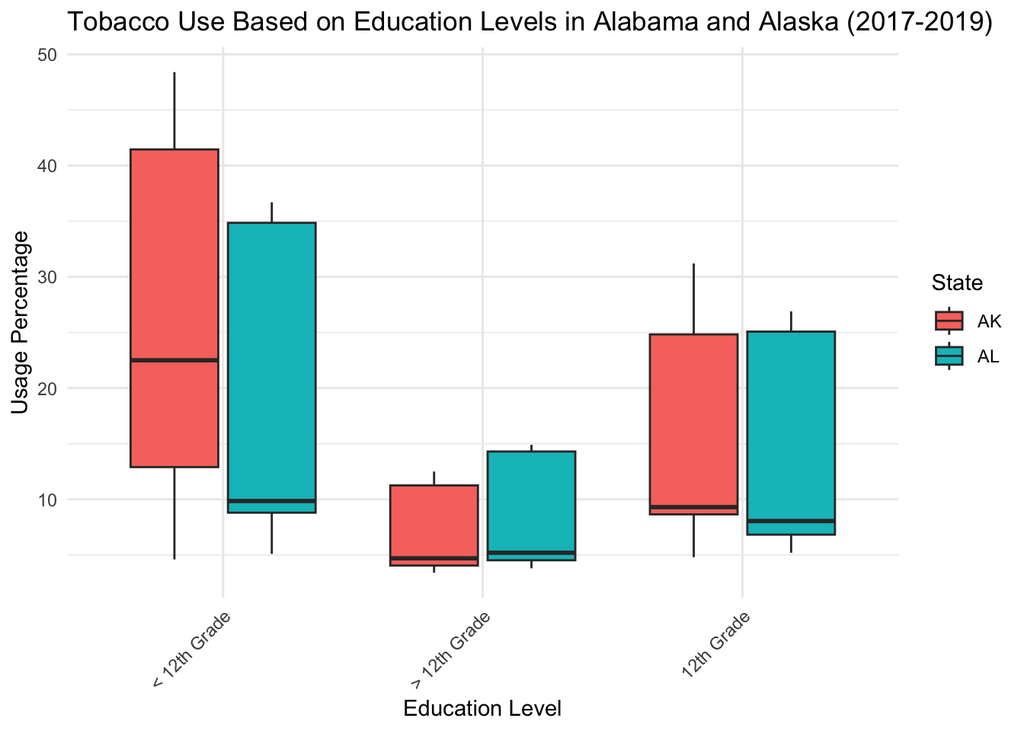

```r
ggplot(Tob.Use %>% filter(year >= 2017, year <= 2019,
                          state %in% c("AL", "AK"),
                          education != "All Grades"),  # Exclude "All Grades"
       aes(x = education, y = data_value, fill = state)) +
  geom_boxplot() +
  labs(
    title = "Tobacco Use Based on Education Levels in Alabama and Alaska (2017-2019)",
    x = "Education Level",
    y = "Usage Percentage",
    fill = "State"
  ) +
  theme_minimal() +
  theme(axis.text.x = element_text(angle = 45, hjust = 1))
```

#7.The mean of different age in different type of tobacco use in Alabama and Alaska

```r
data_filtered <- Tob.Use %>%
  filter(state %in% c('AL', 'AK'), year >= 2017 & year <= 2019) %>%
  filter(!is.na(data_value))
data_filtered$data_value <- as.numeric(as.character(data_filtered$data_value))
age_tobacco_summary <- data_filtered %>%
  group_by(state, topicdesc, age) %>%
  summarise(mean_usage = mean(data_value, na.rm = TRUE),
            count = n())
print(age_tobacco_summary)
```

```
# A tibble: 50 × 5
# Groups:   state, topicdesc [8]
   state topicdesc                age                mean_usage count
   <chr> <chr>                    <chr>                   <dbl> <int>
 1 AK    Cessation (Adults)       All Ages                 55.4    13
 2 AK    Cigarette Use (Adults)   18 to 24 Years           15.5     2
 3 AK    Cigarette Use (Adults)   18 to 44 Years           18.8     2
 4 AK    Cigarette Use (Adults)   25 to 44 Years           22.0     2
 5 AK    Cigarette Use (Adults)   45 to 64 Years           17.7     2
 6 AK    Cigarette Use (Adults)   65 Years and Older       12.6     2
 7 AK    Cigarette Use (Adults)   Age 20 and Older         27.6     6
 8 AK    Cigarette Use (Adults)   Age 25 and Older         29.9     7
 9 AK    Cigarette Use (Adults)   All Ages                 33.4    44
10 AK    E-Cigarette Use (Adults) 18 to 24 Years           18.9     1
# ℹ 40 more rows
```

[figure not shown]

```r
library(ggplot2)
ggplot(age_tobacco_summary, aes(x = age, y = mean_usage, fill = topicdesc)) +
  geom_bar(stat = "identity", position = "dodge") +
  labs(title = "Mean Tobacco Use by Age Group and Type in Alabama (2017-2019)",
       x = "Age Group", y = "Mean Tobacco Use (%)") +
  theme_minimal()+
  theme(axis.text.x = element_text(angle = 45, hjust = 1, size = 8))
```

#8.Comparing Tobacco Use Across Different Types of Use in Alasaka

```r
library(dplyr)
library(ggplot2)
alaska_data <- Tob.Use %>%
  filter(City == 'Alaska', year >= 2017 & year <= 2019) %>%
  filter(!is.na(data_value))
alaska_data$data_value <- as.numeric(as.character(alaska_data$data_value))
anova_result <- aov(data_value ~ topicdesc, data = alaska_data)
summary(anova_result)
```

```
             Df Sum Sq Mean Sq F value   Pr(>F)
topicdesc     3  14741    4914   9.085 1.32e-05 ***
Residuals   168  90870     541
---
Signif. codes:  0 '***' 0.001 '**' 0.01 '*' 0.05 '.' 0.1 ' ' 1
```

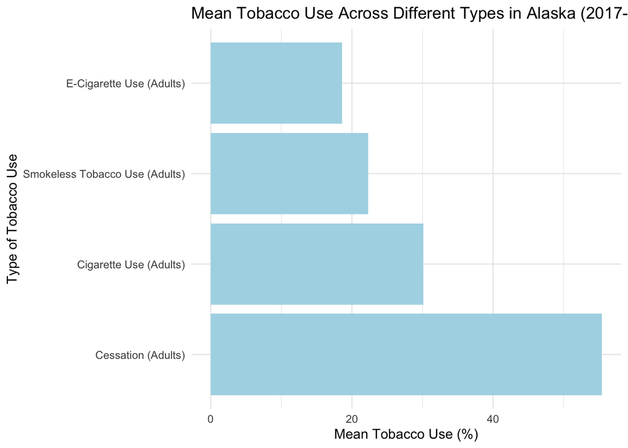

```r
alaska_summary <- alaska_data %>%
  group_by(topicdesc) %>%
  summarise(mean_usage = mean(data_value, na.rm = TRUE),
            sd_usage = sd(data_value, na.rm = TRUE),
            count = n())
ggplot(alaska_summary, aes(x = reorder(topicdesc, -mean_usage), y = mean_usage)) +
  geom_bar(stat = "identity", fill = "lightblue") +
  coord_flip() +
  labs(title = "Mean Tobacco Use Across Different Types in Alaska (2017-2019)",
       x = "Type of Tobacco Use", y = "Mean Tobacco Use (%)") +
  theme_minimal()
```

Result: There are statistically significant differences in the mean tobacco use across the different types of tobacco use in Alaska from 2017 to 2019 (P<0.05).The chart shows a clear difference in the mean usage percentages across different types of tobacco use.The cessation category shows the highest mean, followed by cigarette use, while e-cigarette use has the lowest mean.

#9.Comparing Tobacco Use Across Different Types of Use in Alabama.

```r
library(dplyr)
library(ggplot2)
alabama_data <- Tob.Use %>%
  filter(City == 'Alabama', year >= 2017 & year <= 2019) %>%
  filter(!is.na(data_value))
alabama_data$data_value <- as.numeric(as.character(alabama_data$data_value))
anova_result <- aov(data_value ~ topicdesc, data = alabama_data)
summary(anova_result)
```

```
             Df Sum Sq Mean Sq F value   Pr(>F)
topicdesc     3  17145    5715   10.51 1.65e-06 ***
Residuals   234 127272     544
---
Signif. codes:  0 '***' 0.001 '**' 0.01 '*' 0.05 '.' 0.1 ' ' 1
```

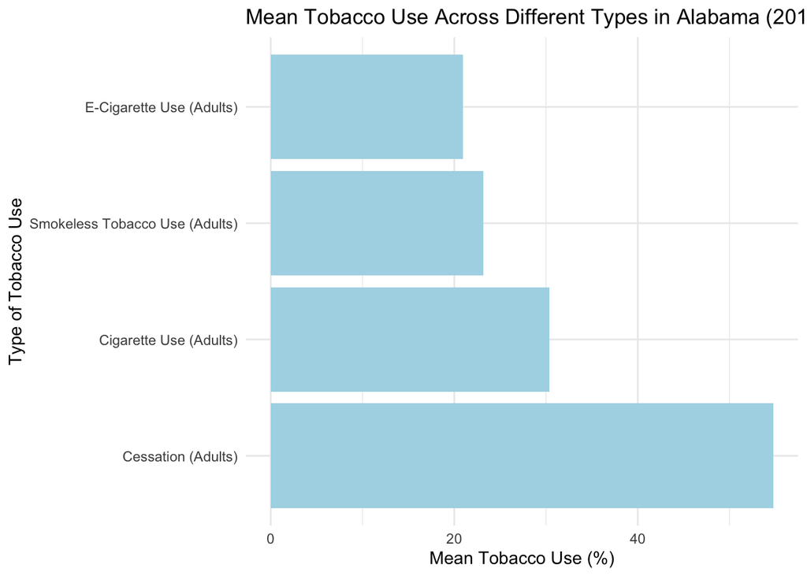

```r
alabama_summary <- alabama_data %>%
  group_by(topicdesc) %>%
  summarise(mean_usage = mean(data_value, na.rm = TRUE),
            sd_usage = sd(data_value, na.rm = TRUE),
            count = n())
ggplot(alabama_summary, aes(x = reorder(topicdesc, -mean_usage), y = mean_usage)) +
  geom_bar(stat = "identity", fill = "lightblue") +
  coord_flip() +  # Flip the bar chart for better readability
  labs(title = "Mean Tobacco Use Across Different Types in Alabama (2017-2019)",
       x = "Type of Tobacco Use", y = "Mean Tobacco Use (%)") +
  theme_minimal()
```

Result: There are statistically significant differences in the mean tobacco use across the different types of tobacco use in Alabama from 2017 to 2019.Cessation has the highest mean, indicating a strong focus on quitting attempts, while e-cigarette use has the lowest mean.